# Лабораторная работа № 2

Дискреционное разграничение прав в Linux. Основные атрибуты

Мальянц Виктория Кареновна

1132246740@rudn.ru

Российский университет дружбы народов

2026-02-22

# Цель работы

- Получение практических навыков работы в консоли с атрибутами файлов, закрепление теоретических основ дискреционного разграничения доступа в современных системах с открытым кодом на базе ОС Linux.

# Задание

- Работа с атрибутами файлов
- Создание таблицы “Установленные права и разрешенные действия”
- Создание таблицы “Минимальные права для совершения операций”

# Выполнение лабораторной работы

## Работа с атрибутами файлов

- В установленной при выполнении предыдущей лабораторной работы операционной системе создаю учётную запись пользователя guest (рис. 1).

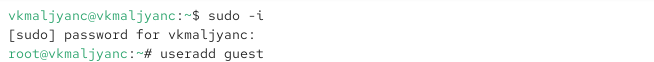

Создание новой учетной записи

## Работа с атрибутами файлов

- Создаю пароль для пользователя guest (рис. 2).

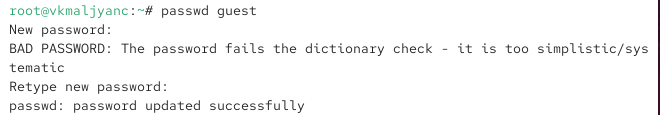

Создание пароля для пользователя guest

## Работа с атрибутами файлов

- Вошла в систему от имени пользователя guest (рис. 3).

[figure not shown]

Вход в систему от имени пользователя guest

## Работа с атрибутами файлов

- Определяю директорию, в которой нахожусь, командой pwd. Она является домашней директорией (рис. 4).

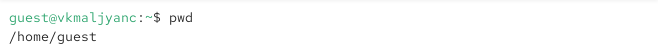

Определение текущей директории

## Работа с атрибутами файлов

- Уточняю имя моего пользователя, его группу, а также группы, куда входит пользователь, командой id (рис. 6).

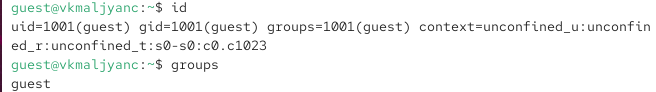

Команда id

## Работа с атрибутами файлов

- Определяю существующие в системе директории командой ls -l /home/ (рис. 9).

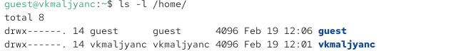

Команда ls -l /home/

## Работа с атрибутами файлов

- Проверяю, какие расширенные атрибуты установлены на поддиректориях, находящихся в директории /home, командой: lsattr /home. Не удалось увидеть (рис. 10).

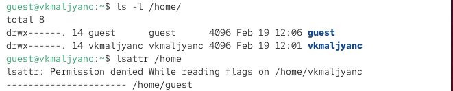

Команда lsattr /home

## Работа с атрибутами файлов

- Создаю в домашней директории поддиректорию dir1 командой mkdir dir1. Определяю командами ls -l и lsattr, какие права доступа и расши- ренные атрибуты были выставлены на директорию dir1. (рис. 11).

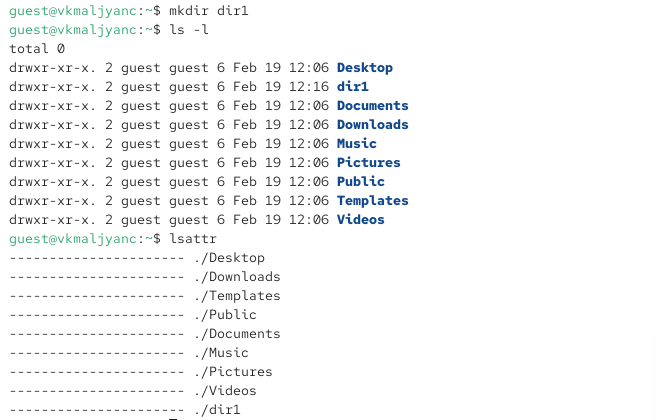

Команды mkdir dir1, ls -l и lsattr

## Работа с атрибутами файлов

- Снимаю с директории dir1 все атрибуты командой chmod 000 dir1 и проверяю с её помощью правильность выполнения команды ls -l (рис. 12).

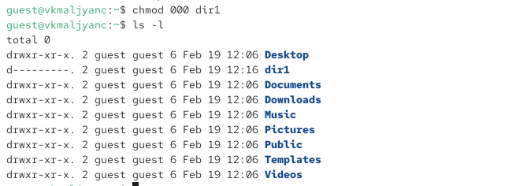

Команды chmod 000 dir1 и ls -l

## Работа с атрибутами файлов

- Пытаюсь создать в директории dir1 файл file1 командой echo “test” > /home/guest/dir1/file1. Проверяю командой ls -l /home/guest/dir1 действительно ли файл file1 не находится внутри директории dir1 (рис. 13).

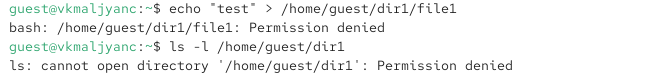

Команды echo “test” > /home/guest/dir1/file1 и ls -l /home/guest/dir1

## Создание таблицы “Установленные права и разрешенные действия”

- Определяю опытным путем, какие операции разрешены, а какие нет, при установлении прав на директорию и файл (рис. 14).

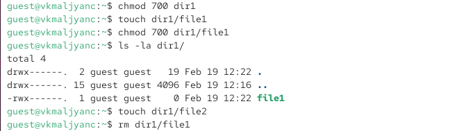

Проверка выполнения операций

## Создание таблицы “Установленные права и разрешенные действия”

- Продолжаю проверять какие операции будут выполняться (рис. 15).

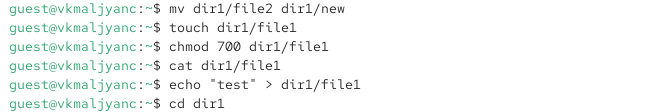

Продолжение проверки выполнения операций

## Создание таблицы “Минимальные права для совершения операций”

[output not shown]

# Выводы

Я получила практические навыки работы в консоли с атрибутами файлов, закрепила теоретические основы дискреционного разграничения доступа в современных системах с открытым кодом на базе ОС Linux.

# Спасибо за внимание